# Red Wines Exploration by J.T. Robinson

This report explores a dataset containing the chemical features of nearly 1,600 red wines.

# Univariate Plots Section

```
## 'data.frame':    1599 obs. of  13 variables:
##  $ X                   : int  1 2 3 4 5 6 7 8 9 10 ...
##  $ fixed.acidity       : num  7.4 7.8 7.8 11.2 7.4 7.4 7.9 7.3 7.8 7.5 ...
##  $ volatile.acidity    : num  0.7 0.88 0.76 0.28 0.7 0.66 0.6 0.65 0.58 0.5 ...
##  $ citric.acid         : num  0 0 0.04 0.56 0 0 0.06 0 0.02 0.36 ...
##  $ residual.sugar      : num  1.9 2.6 2.3 1.9 1.9 1.8 1.6 1.2 2 6.1 ...
##  $ chlorides           : num  0.076 0.098 0.092 0.075 0.076 0.075 0.069 0.065 0.073 0.071 ...
##  $ free.sulfur.dioxide : num  11 25 15 17 11 13 15 15 9 17 ...
##  $ total.sulfur.dioxide: num  34 67 54 60 34 40 59 21 18 102 ...
##  $ density             : num  0.998 0.997 0.997 0.998 0.998 ...
##  $ pH                  : num  3.51 3.2 3.26 3.16 3.51 3.51 3.3 3.39 3.36 3.35 ...
##  $ sulphates           : num  0.56 0.68 0.65 0.58 0.56 0.56 0.46 0.47 0.57 0.8 ...
##  $ alcohol             : num  9.4 9.8 9.8 9.8 9.4 9.4 9.4 10 9.5 10.5 ...
##  $ quality             : int  5 5 5 6 5 5 5 7 7 5 ...
```

```
##        X          fixed.acidity   volatile.acidity  citric.acid
##  Min.   :   1.0   Min.   : 4.60   Min.   :0.1200   Min.   :0.000
##  1st Qu.: 400.5   1st Qu.: 7.10   1st Qu.:0.3900   1st Qu.:0.090
##  Median : 800.0   Median : 7.90   Median :0.5200   Median :0.260
##  Mean   : 800.0   Mean   : 8.32   Mean   :0.5278   Mean   :0.271
##  3rd Qu.:1199.5   3rd Qu.: 9.20   3rd Qu.:0.6400   3rd Qu.:0.420
##  Max.   :1599.0   Max.   :15.90   Max.   :1.5800   Max.   :1.000
##  residual.sugar     chlorides       free.sulfur.dioxide
##  Min.   : 0.900   Min.   :0.01200   Min.   : 1.00
##  1st Qu.: 1.900   1st Qu.:0.07000   1st Qu.: 7.00
##  Median : 2.200   Median :0.07900   Median :14.00
##  Mean   : 2.539   Mean   :0.08747   Mean   :15.87
##  3rd Qu.: 2.600   3rd Qu.:0.09000   3rd Qu.:21.00
##  Max.   :15.500   Max.   :0.61100   Max.   :72.00
##  total.sulfur.dioxide    density             pH          sulphates
##  Min.   :  6.00       Min.   :0.9901   Min.   :2.740   Min.   :0.3300
##  1st Qu.: 22.00       1st Qu.:0.9956   1st Qu.:3.210   1st Qu.:0.5500
##  Median : 38.00       Median :0.9968   Median :3.310   Median :0.6200
##  Mean   : 46.47       Mean   :0.9967   Mean   :3.311   Mean   :0.6581
##  3rd Qu.: 62.00       3rd Qu.:0.9978   3rd Qu.:3.400   3rd Qu.:0.7300
##  Max.   :289.00       Max.   :1.0037   Max.   :4.010   Max.   :2.0000
##     alcohol         quality
##  Min.   : 8.40   Min.   :3.000
##  1st Qu.: 9.50   1st Qu.:5.000
##  Median :10.20   Median :6.000
##  Mean   :10.42   Mean   :5.636
##  3rd Qu.:11.10   3rd Qu.:6.000
##  Max.   :14.90   Max.   :8.000
```

This dataset consists of 13 red wine features across nearly 1,600 observations.

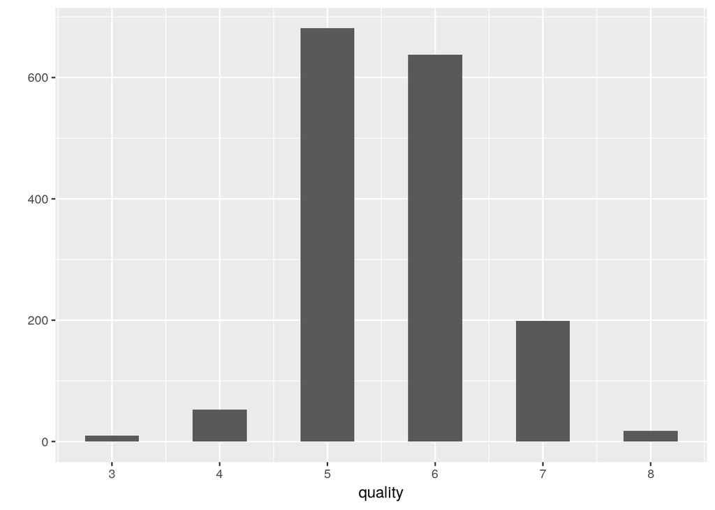

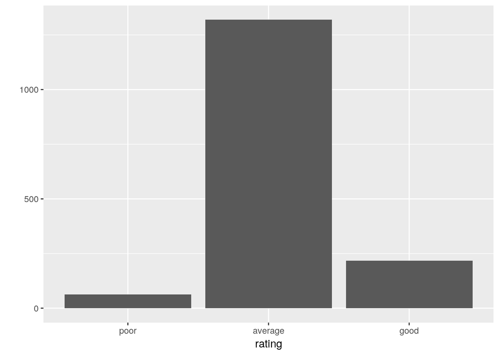

Most wines have a quality rating between 5 and 6 on a 1 to 10 scale. There are no wines in the dataset with a quality rating under 3 and none have a rating above 8. I’ve created a rating variable to break down the wine quality into three distinct groups of poor, average, and good. Overall this plot suggeststhat most red wines are average in quality.

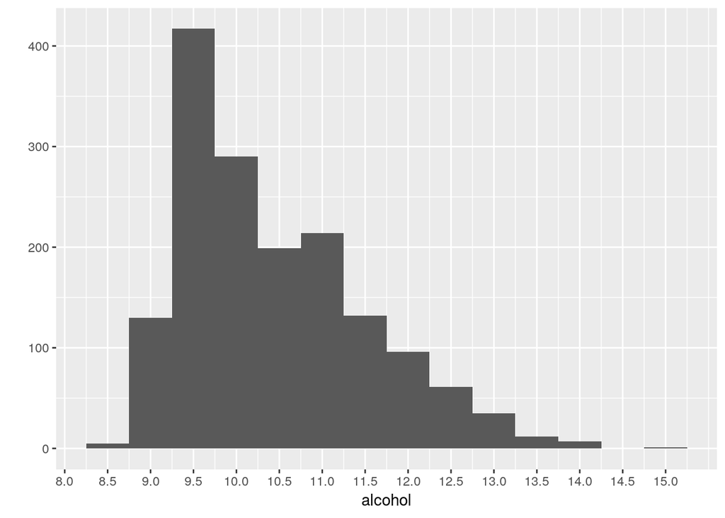

The alcohol content plot appears to be right-skewed with the highest number of wines showing between roughly 9.5 - 10.25% alcohol content. I wonder what the plots would look like across the characteristics of density, pH, and quality.

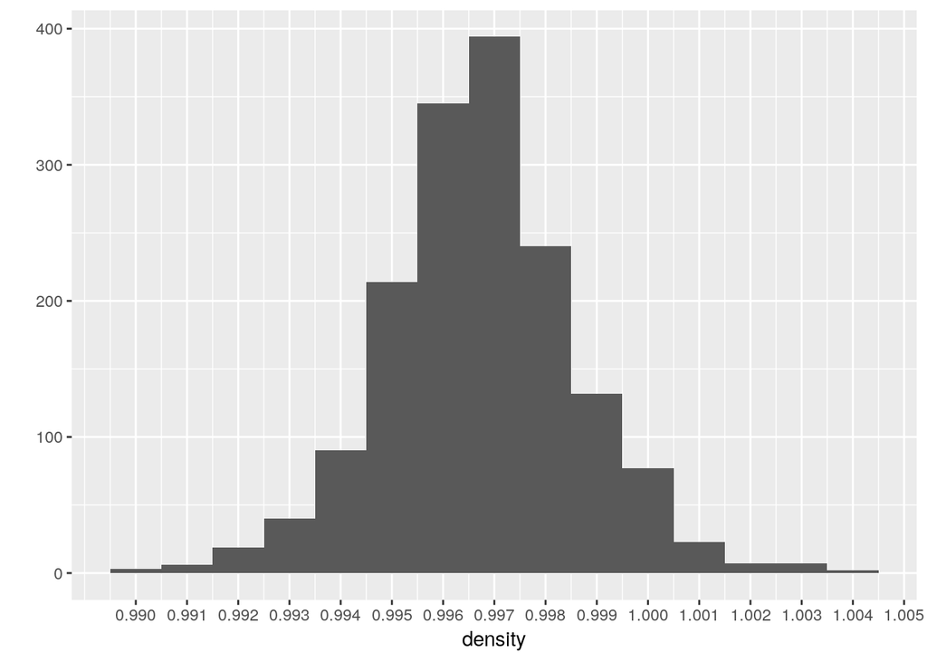

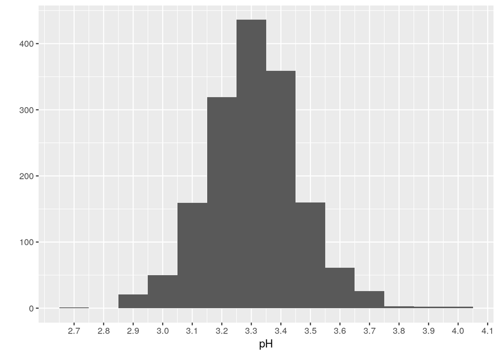

Most red wines have a density of 0.997 g / $cm^{3}$ with a similar number of wines above and below 0.997 indicating a normal distribution. The pH plot also shows a normal distribution with most wines having a pH of 3.3. Next we’ll examine the amounts of residual sugar in the wines.

```
##    Min. 1st Qu.  Median    Mean 3rd Qu.    Max.
##   0.900   1.900   2.200   2.539   2.600  15.500
```

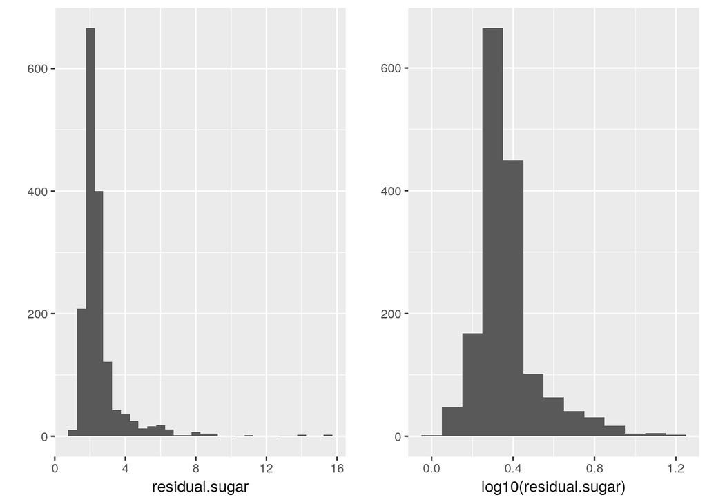

The plot above shows that most of the red wines in the dataset contain very little residual sugar and as a result displays a long-tail distribution. Residual sugar is the amount of sugar remaining after fermentation stops. The initial plot shows long-tailed data. I’ve performed a log10 transform to deliver a more normal distribution. Let’s examine the acidity of the red wines.

```
##    Min. 1st Qu.  Median    Mean 3rd Qu.    Max.
##    4.60    7.10    7.90    8.32    9.20   15.90
```

```
##    Min. 1st Qu.  Median    Mean 3rd Qu.    Max.
##  0.1200  0.3900  0.5200  0.5278  0.6400  1.5800
```

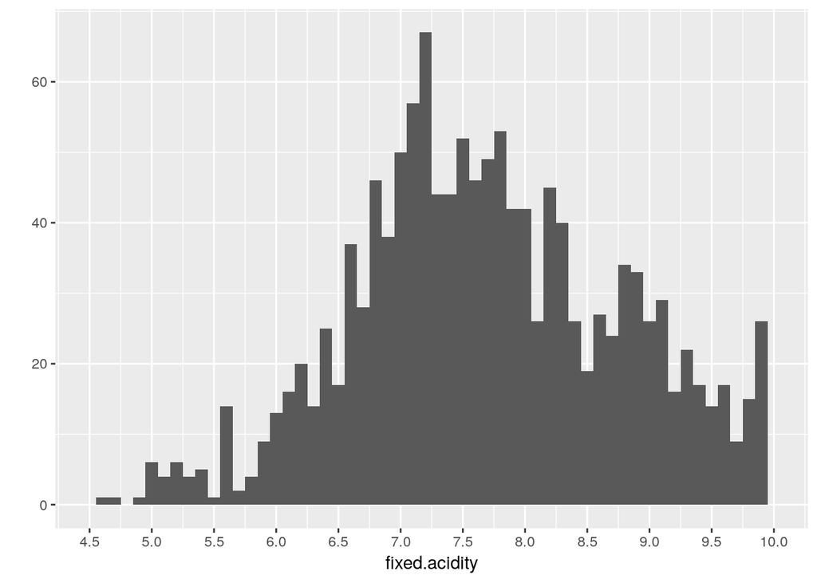

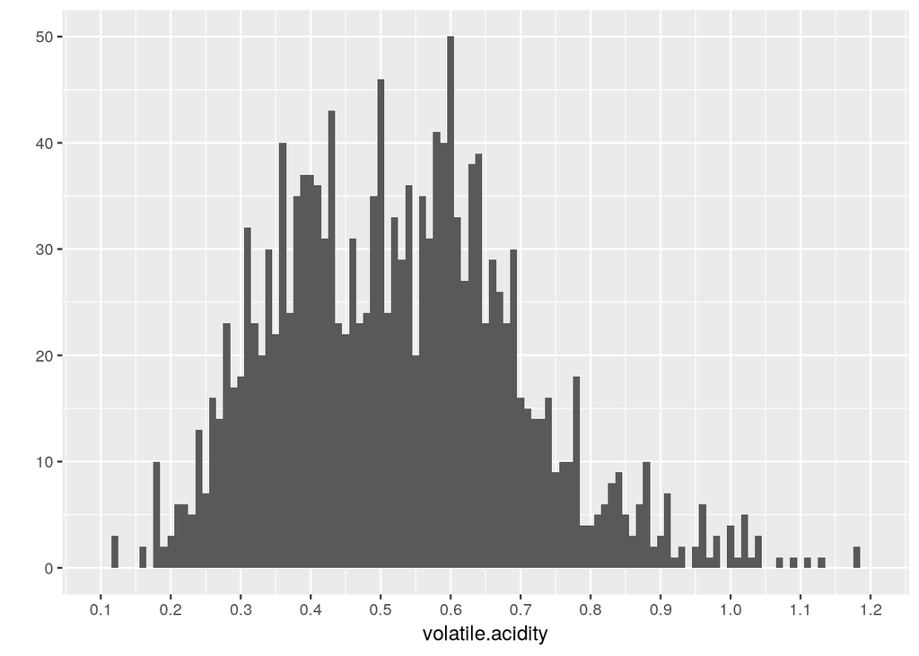

The plots on acidity above show fixed and volatile acidity of the observed red wines. In the case of fixed acidity, tartaric acids involved with wine are fixed or nonvolatile (do not evaporate readily). The volatile acidity indicates the amount of acetic acid in the wine, which at too high of levels can lead to an unpleasant, vinegar taste. Most red wines have a fixed acidity between 7 & 9 g / $dm^{3}$ while most have a volatile acidity between 0.4 & 0.65 g / $dm^{3}$ indicating that most red wines do not have high concentrations of acids that evaporate readily and do not have a vinegar taste from high acetic acid levels. In the upcoming plots we’ll examine the sulfur dioxide levels of the observed red wines.

```
##    Min. 1st Qu.  Median    Mean 3rd Qu.    Max.
##    1.00    7.00   14.00   15.87   21.00   72.00
```

```
##    Min. 1st Qu.  Median    Mean 3rd Qu.    Max.
##    6.00   22.00   38.00   46.47   62.00  289.00
```

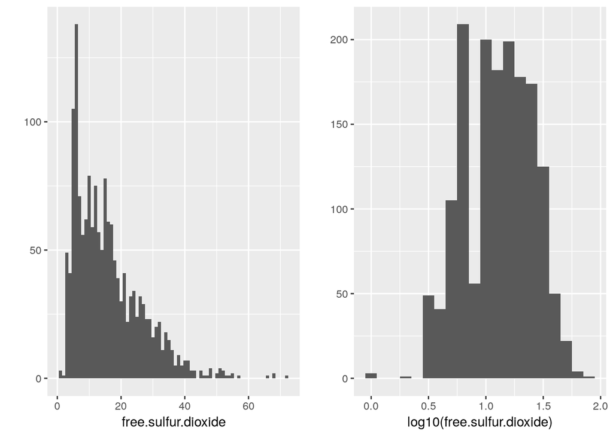

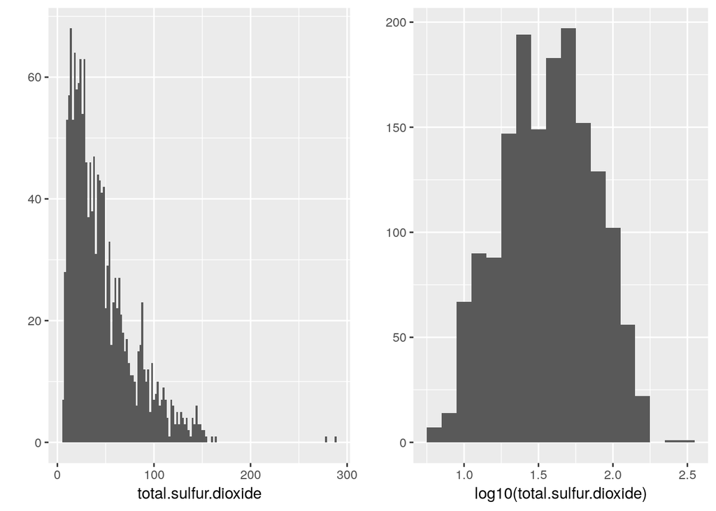

```
##    Min. 1st Qu.  Median    Mean 3rd Qu.    Max.
##  0.3300  0.5500  0.6200  0.6581  0.7300  2.0000
```

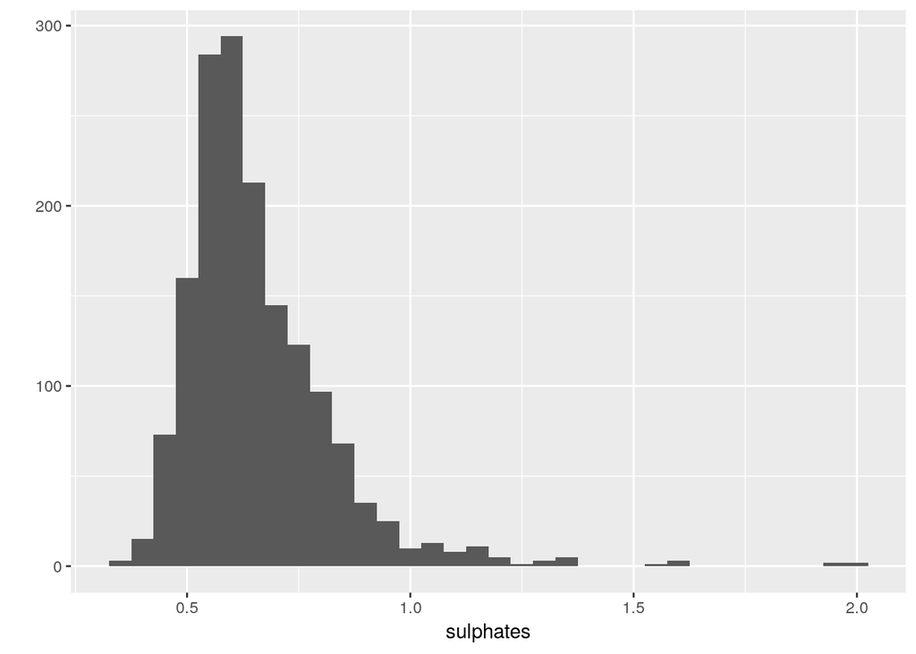

Sulphates are a wine additive which can contribute to sulfur dioxide gas (S02) levels, wich acts as an antimicrobial and antioxidant. Most wines have a suplhate content between .5 and 1 g / $dm^{3}$ with a mean of .65 g / $dm^{3}$

```
##    Min. 1st Qu.  Median    Mean 3rd Qu.    Max.
## 0.01200 0.07000 0.07900 0.08747 0.09000 0.61100
```

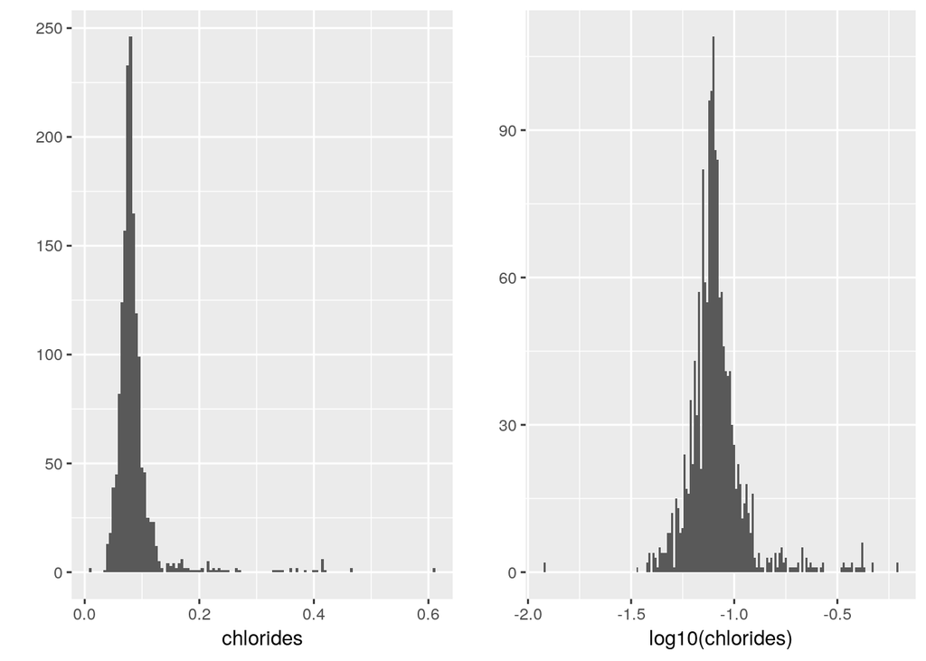

This plot indicates the amount of chlorides in each red wine observed. Chlorides refer to the amount of salt in the wine. Our dataset contain wines with chloride content between .01 and .6 g / $dm^{3}$. I’ve applied a logarithmic transform to the chlorides data to achieve a more normal distribution. Most wines have chloride content between .04 and .12 g / $dm^{3}$.

# Univariate Analysis

### What is the structure of your dataset?

There are 1,599 wines in the dataset with 13 features (fixed acidity, volatile acidity, citric acid, residual sugar, chlorides, free sulfur dioxide, total sulfur dioxide, density, pH, sulphates, alcohol, quality, and X.) The dataset does not contained any ordered factor variables.

### What is/are the main feature(s) of interest in your dataset?

The main feature of interest to me in the data is the quality and how the various features of the wines contribute to the quality of the wine. Depending on how these features are correlated to each other a predictive model can be created for wine quality.

### What other features in the dataset do you think will help support your investigation into your feature(s) of interest?

Acidity, residual sugar, sulphates and chlorides are likely to contribute to the quality. I think these features contribute the most to the quality of the wine due to their direct correlation to the wine’s taste

### Of the features you investigated, were there any unusual distributions? Did you perform any operations on the data to tidy, adjust, or change the form of the data? If so, why did you do this?

# Bivariate Plots Section

```
## # A tibble: 11 x 2
##    rowname              quality
##    <chr>                  <dbl>
##  1 fixed.acidity         0.124
##  2 volatile.acidity     -0.391
##  3 citric.acid           0.226
##  4 residual.sugar        0.0137
##  5 chlorides            -0.129
##  6 free.sulfur.dioxide  -0.0507
##  7 total.sulfur.dioxide -0.185
##  8 pH                   -0.0577
##  9 sulphates             0.251
## 10 alcohol               0.476
## 11 density              -0.175
```

The correlation matrix shows that alcohol & volatile acidity have the strongest correlation with wine quality.

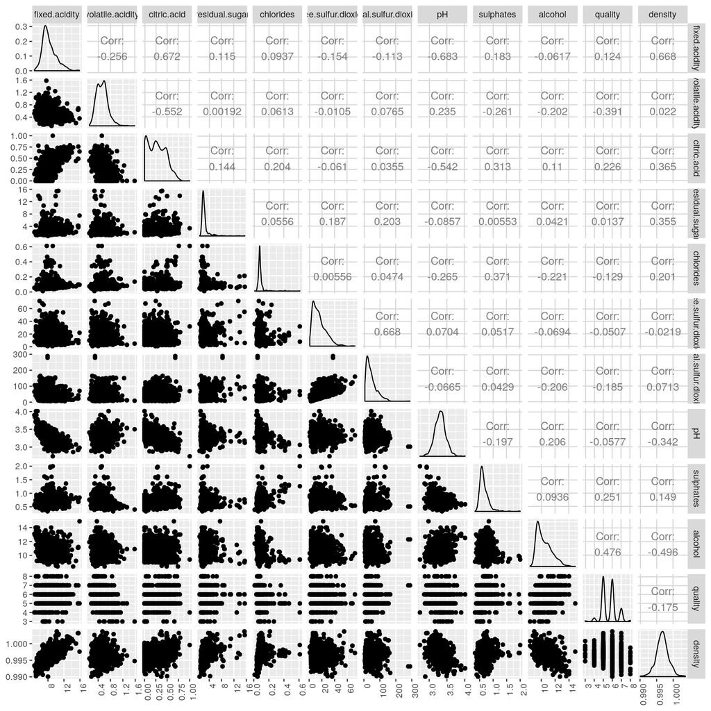

The fixed acidity and pH level of the wines correlate to each other. This makes sense because the higher the fixed acidity the lower pH level of the wine. pH is measured on a scale from 0 (very acidic) to 14 (very basic). There are strong correlations between citric acid and fixed acidity, citric acid and volatile acidity, and citric acid and pH. Strong correlations can also be seen across free sulfur dioxide and total sulfur dioxide, density and fixed acidity, alcohol and density, and alcohol and quality. There are moderate correlations between between the features of quality and volatile acidity, sulphates and citric acid,and sulphates and chlorides.

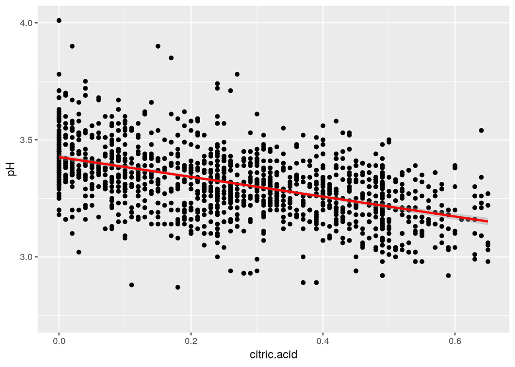

As the level of citric acid increases the pH level decreases. There are some red wines that have high citric acid content and also have high pH levels. Overall the plot indicates a negative slope. I would like to fit this data to a linear regression model to see how much of a contributor citric acid is to the pH level.

```
##
## Call:
## lm(formula = pH ~ citric.acid, data = reds)
##
## Residuals:
##      Min       1Q   Median       3Q      Max
## -0.50025 -0.07733 -0.00570  0.08251  0.58251
##
## Coefficients:
##              Estimate Std. Error t value Pr(>|t|)
## (Intercept)  3.427491   0.005562  616.25   <2e-16 ***
## citric.acid -0.429477   0.016668  -25.77   <2e-16 ***
## ---
## Signif. codes:  0 '***' 0.001 '**' 0.01 '*' 0.05 '.' 0.1 ' ' 1
##
## Residual standard error: 0.1298 on 1597 degrees of freedom
## Multiple R-squared:  0.2937, Adjusted R-squared:  0.2932
## F-statistic:   664 on 1 and 1597 DF,  p-value: < 2.2e-16
```

The linear regression model shows a fairly linear relationship between citric acid and pH. For every g / $dm^{3}$ of citric acid there is a corresponding decrease of .43 of the pH level. The R-squared values indicate that the citric acid level contributes about 29% of the variance in pH. I’m curious to see how the citric acid affects the fixed acidity of the wine.

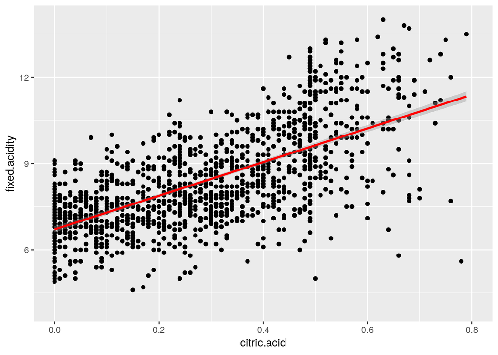

This plot shows a positive slope between citric acid and fixed acidity. As the level of citric acid increases the fixed acidity level also increases.

```
##
## Call:
## lm(formula = fixed.acidity ~ citric.acid, data = reds)
##
## Residuals:
##     Min      1Q  Median      3Q     Max
## -5.7756 -0.8148 -0.0335  0.8063  5.9654
##
## Coefficients:
##             Estimate Std. Error t value Pr(>|t|)
## (Intercept)  6.69282    0.05529  121.05   <2e-16 ***
## citric.acid  6.00356    0.16569   36.23   <2e-16 ***
## ---
## Signif. codes:  0 '***' 0.001 '**' 0.01 '*' 0.05 '.' 0.1 ' ' 1
##
## Residual standard error: 1.29 on 1597 degrees of freedom
## Multiple R-squared:  0.4512, Adjusted R-squared:  0.4508
## F-statistic:  1313 on 1 and 1597 DF,  p-value: < 2.2e-16
```

The model shows that for every g / $dm^{3}$ of citric acid there is an increase of about 6 g / $dm^{3}$ of fixed acidity. The model indicates that the citric acid contributes about 45% of the variance in fixed acidity.

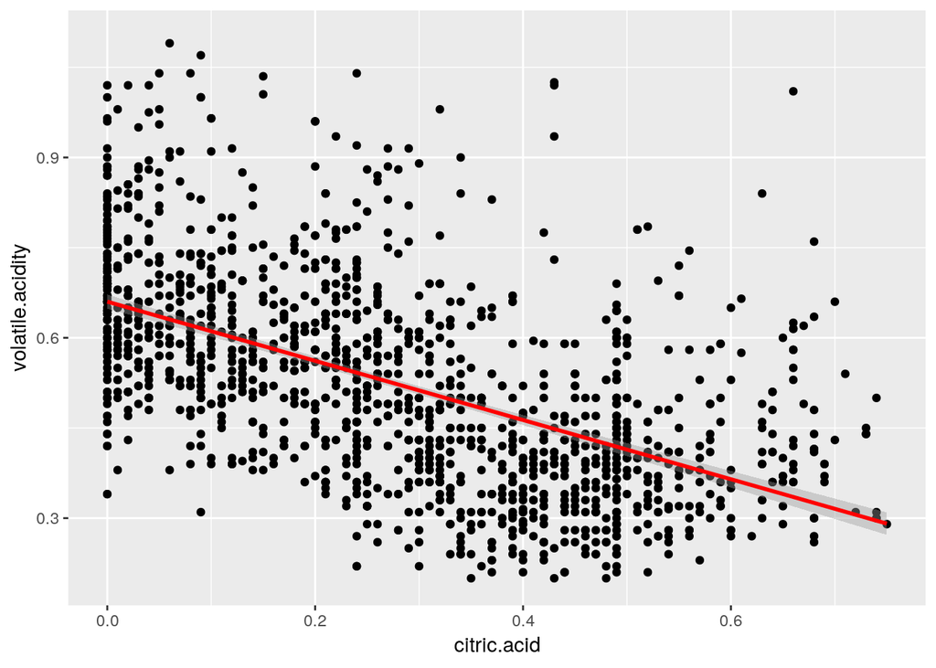

In this plot it appears that the volatile acidity actually goes down with an increase in citric acid. Here we see a negative slope indicating the inverse relationship.

```
##
## Call:
## lm(formula = volatile.acidity ~ citric.acid, data = reds)
##
## Residuals:
##      Min       1Q   Median       3Q      Max
## -0.36879 -0.09832 -0.01549  0.07519  0.91456
##
## Coefficients:
##              Estimate Std. Error t value Pr(>|t|)
## (Intercept)  0.665435   0.006398  104.01   <2e-16 ***
## citric.acid -0.507850   0.019172  -26.49   <2e-16 ***
## ---
## Signif. codes:  0 '***' 0.001 '**' 0.01 '*' 0.05 '.' 0.1 ' ' 1
##
## Residual standard error: 0.1493 on 1597 degrees of freedom
## Multiple R-squared:  0.3053, Adjusted R-squared:  0.3048
## F-statistic: 701.7 on 1 and 1597 DF,  p-value: < 2.2e-16
```

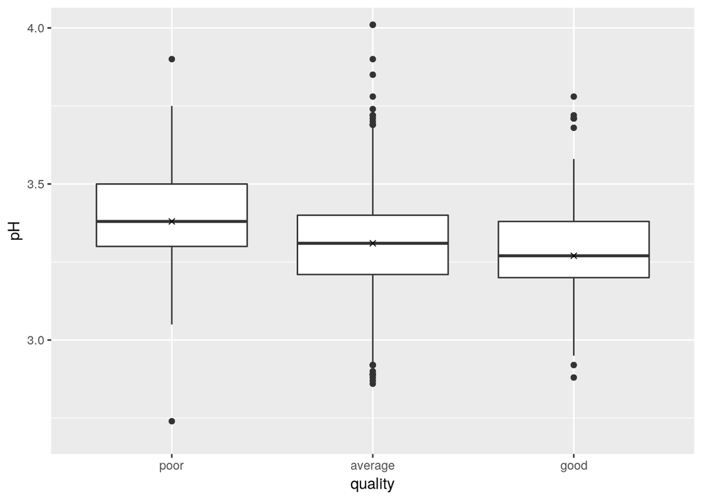

```
## reds$rating: poor
##    Min. 1st Qu.  Median    Mean 3rd Qu.    Max.
##   2.740   3.300   3.380   3.384   3.500   3.900
## --------------------------------------------------------
## reds$rating: average
##    Min. 1st Qu.  Median    Mean 3rd Qu.    Max.
##   2.860   3.210   3.310   3.311   3.400   4.010
## --------------------------------------------------------
## reds$rating: good
##    Min. 1st Qu.  Median    Mean 3rd Qu.    Max.
##   2.880   3.200   3.270   3.289   3.380   3.780
```

This boxplot shows that pH level becomes lower as the wine quality gets better suggesting that higher levels of acidity in a wine could improve the quality but I need to perform more analysis to confirm the hypothesis.

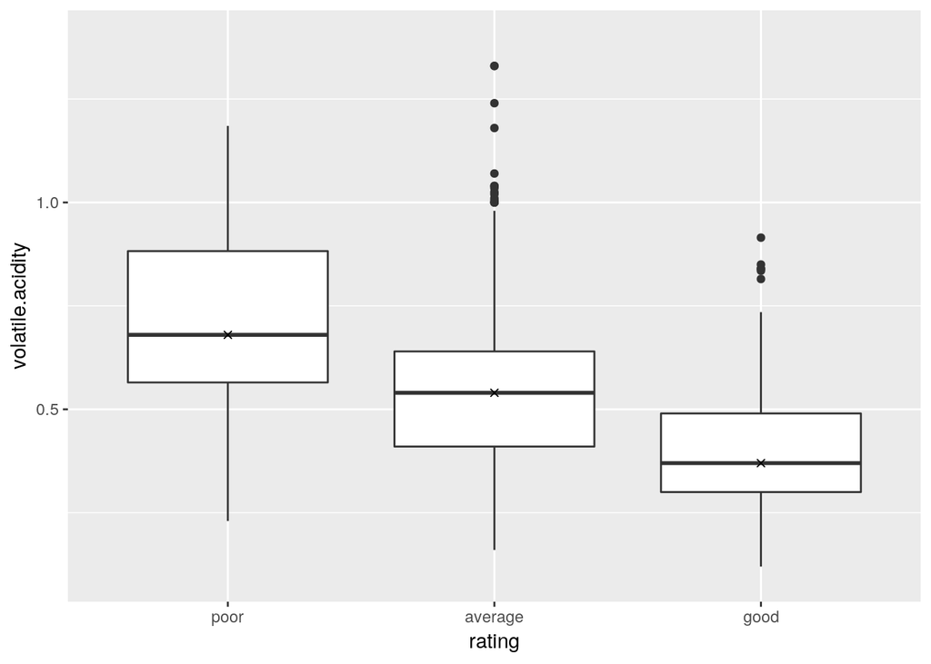

```
## reds$rating: poor
##    Min. 1st Qu.  Median    Mean 3rd Qu.    Max.
##  0.2300  0.5650  0.6800  0.7242  0.8825  1.5800
## --------------------------------------------------------
## reds$rating: average
##    Min. 1st Qu.  Median    Mean 3rd Qu.    Max.
##  0.1600  0.4100  0.5400  0.5386  0.6400  1.3300
## --------------------------------------------------------
## reds$rating: good
##    Min. 1st Qu.  Median    Mean 3rd Qu.    Max.
##  0.1200  0.3000  0.3700  0.4055  0.4900  0.9150
```

Volatile acidity appears to have a negative impact on wine quality. The poor quality have a mean volatile acidty of .72 g / $dm^{3}$ versus a mean of only 0.41 g / $dm^{3}$ for wines of good quality.

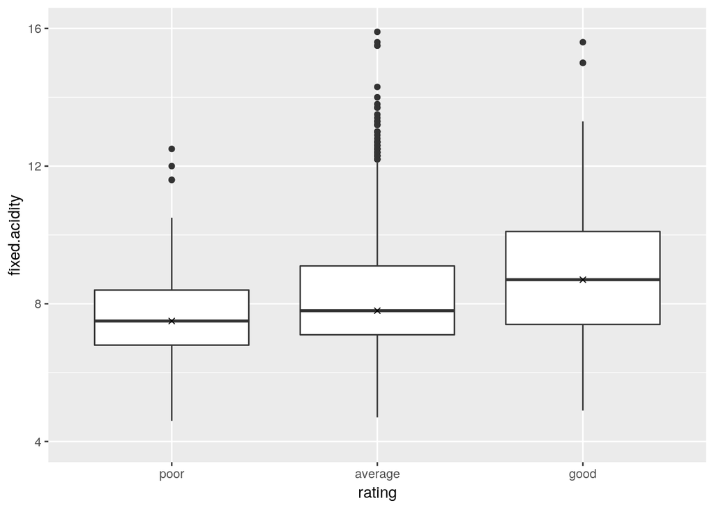

```
## reds$rating: poor
##    Min. 1st Qu.  Median    Mean 3rd Qu.    Max.
##   4.600   6.800   7.500   7.871   8.400  12.500
## --------------------------------------------------------
## reds$rating: average
##    Min. 1st Qu.  Median    Mean 3rd Qu.    Max.
##   4.700   7.100   7.800   8.254   9.100  15.900
## --------------------------------------------------------
## reds$rating: good
##    Min. 1st Qu.  Median    Mean 3rd Qu.    Max.
##   4.900   7.400   8.700   8.847  10.100  15.600
```

The fixed acidity is higher in red wines with a quality rating of good indicating a positive correlation. The mean fixed acidity of wines rated good is roughly 8.8 g / $dm^{3}$ and 7.9 g / $dm^{3}$ in wines rated as poor.

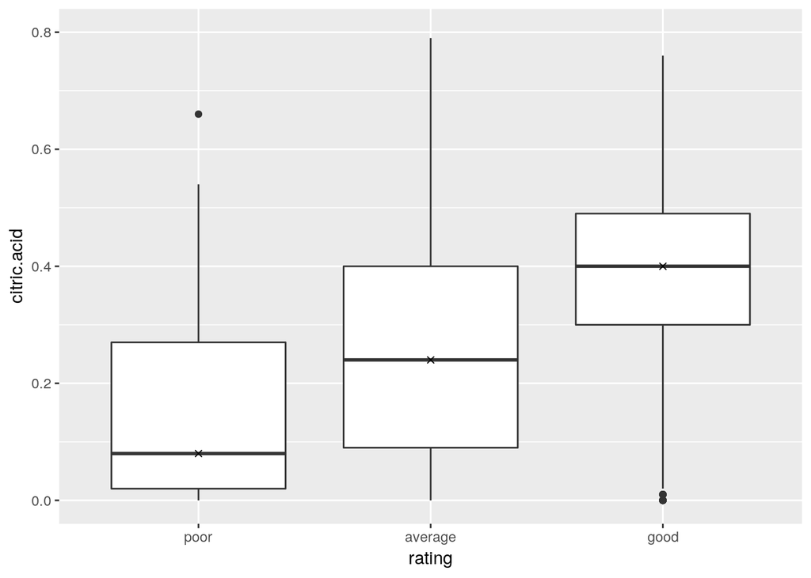

```
## reds$rating: poor
##    Min. 1st Qu.  Median    Mean 3rd Qu.    Max.
##  0.0000  0.0200  0.0800  0.1737  0.2700  1.0000
## --------------------------------------------------------
## reds$rating: average
##    Min. 1st Qu.  Median    Mean 3rd Qu.    Max.
##  0.0000  0.0900  0.2400  0.2583  0.4000  0.7900
## --------------------------------------------------------
## reds$rating: good
##    Min. 1st Qu.  Median    Mean 3rd Qu.    Max.
##  0.0000  0.3000  0.4000  0.3765  0.4900  0.7600
```

Citric acid also has a positive correlation with quality. The wines rated poor have a median citric acid content of only .08 against a median value of .4 for wines rated good.

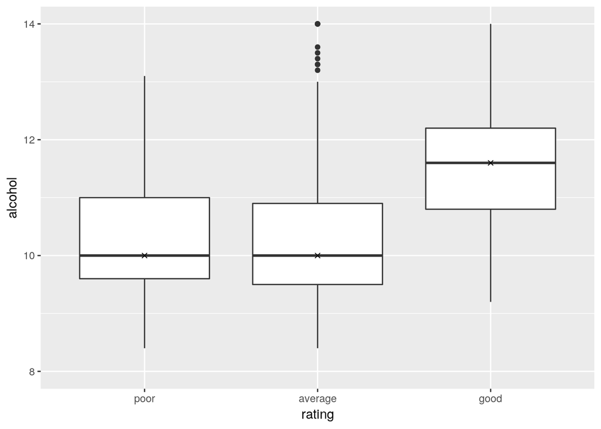

```
## reds$rating: poor
##    Min. 1st Qu.  Median    Mean 3rd Qu.    Max.
##    8.40    9.60   10.00   10.22   11.00   13.10
## --------------------------------------------------------
## reds$rating: average
##    Min. 1st Qu.  Median    Mean 3rd Qu.    Max.
##    8.40    9.50   10.00   10.25   10.90   14.90
## --------------------------------------------------------
## reds$rating: good
##    Min. 1st Qu.  Median    Mean 3rd Qu.    Max.
##    9.20   10.80   11.60   11.52   12.20   14.00
```

The plot of the correlation between alcohol and quality is interesting. It appears that the average alcohol content is roughly the same for both poor and average wine quality ratings at 10%. While the average alcohol content of wines rated good quality is nearly 12%.

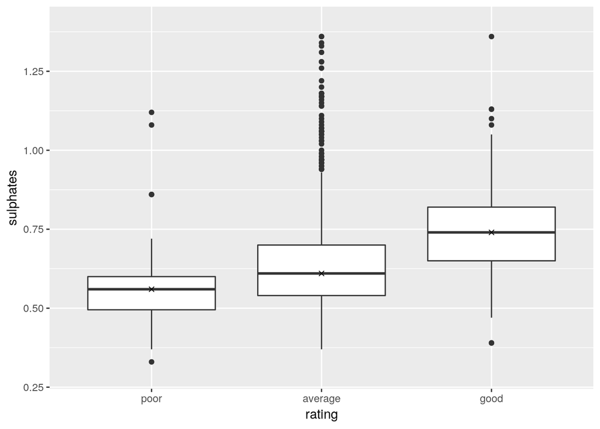

```
## reds$rating: poor
##    Min. 1st Qu.  Median    Mean 3rd Qu.    Max.
##  0.3300  0.4950  0.5600  0.5922  0.6000  2.0000
## --------------------------------------------------------
## reds$rating: average
##    Min. 1st Qu.  Median    Mean 3rd Qu.    Max.
##  0.3700  0.5400  0.6100  0.6473  0.7000  1.9800
## --------------------------------------------------------
## reds$rating: good
##    Min. 1st Qu.  Median    Mean 3rd Qu.    Max.
##  0.3900  0.6500  0.7400  0.7435  0.8200  1.3600
```

Sulphates have a positive correlation with wine quality too. The median sulphate content of wines rated poor is .56 g / $dm^{3}$ and .74 g / $dm^{3}$ for wines rated good.

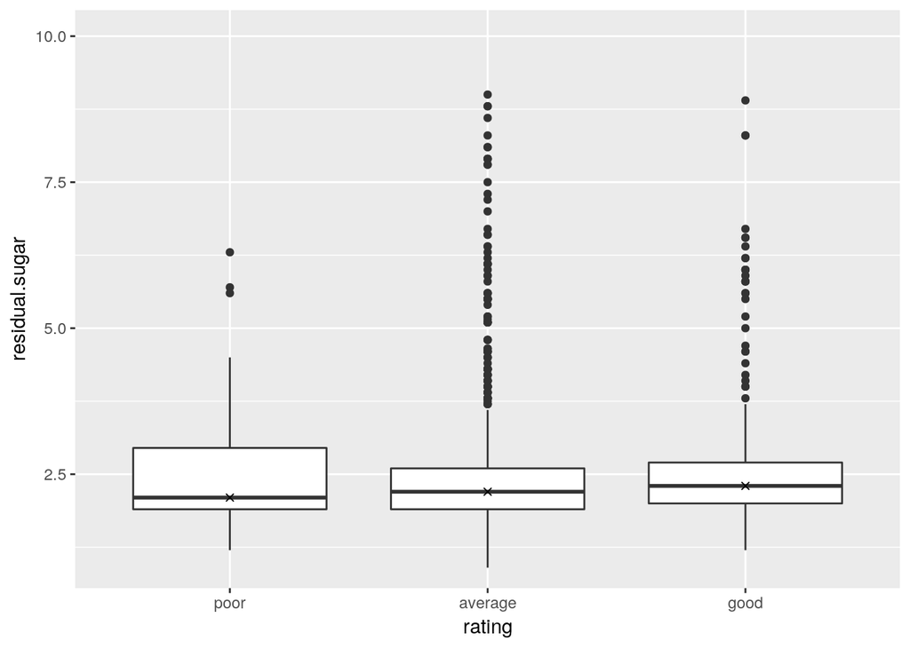

```
## reds$rating: poor
##    Min. 1st Qu.  Median    Mean 3rd Qu.    Max.
##   1.200   1.900   2.100   2.685   2.950  12.900
## --------------------------------------------------------
## reds$rating: average
##    Min. 1st Qu.  Median    Mean 3rd Qu.    Max.
##   0.900   1.900   2.200   2.504   2.600  15.500
## --------------------------------------------------------
## reds$rating: good
##    Min. 1st Qu.  Median    Mean 3rd Qu.    Max.
##   1.200   2.000   2.300   2.709   2.700   8.900
```

Interestingly there does not appear to be any correlation between residual sugar and wine quality and is fairly even across all ratings. The average across all three ratings is between 2.5 g / $dm^{3}$ and 2.7 g / $dm^{3}$. I would have thought that because sugar content has an effect on taste that the quality would change accordingly based on that sugar content.

# Bivariate Analysis

### Did you observe any interesting relationships between the other features (not the main feature(s) of interest)?

Citric acid and fixed acidity are positively correlated while pH and citric acid are negatively correlated.

### What was the strongest relationship you found?

The strongest correlation across all features is between density and fixed acidity as well as total sulfur dioxide and free sulfur dioxide. Both relationships have a correlation value of .67.

# Multivariate Plots Section

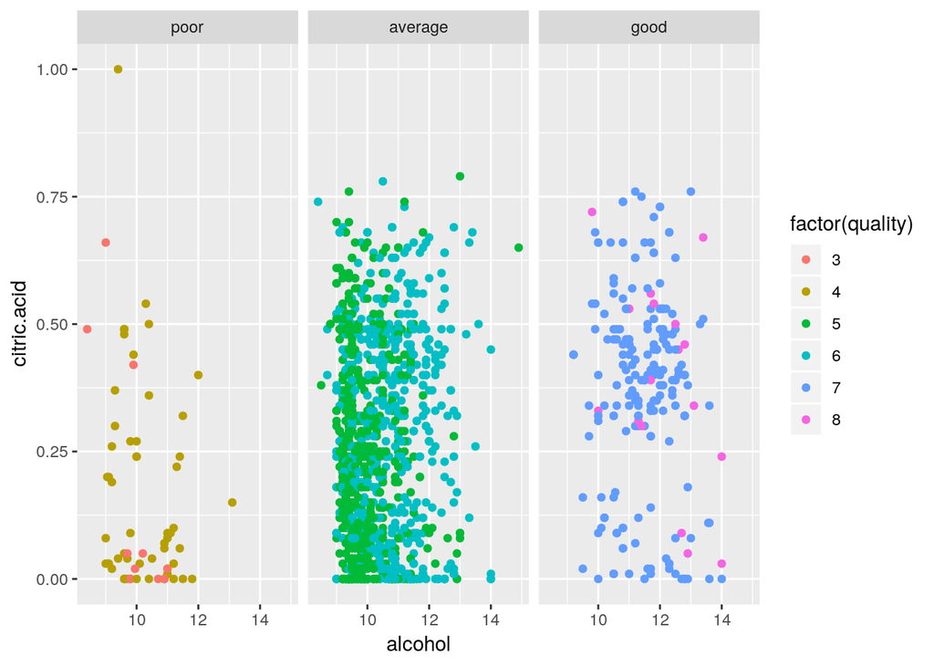

There is not a strong correlation between alcohol and citric acid across the three ratings of wines. There does appear to be more wines with higher concentrations of citric acid in the good category than wines in the poor and average categories.

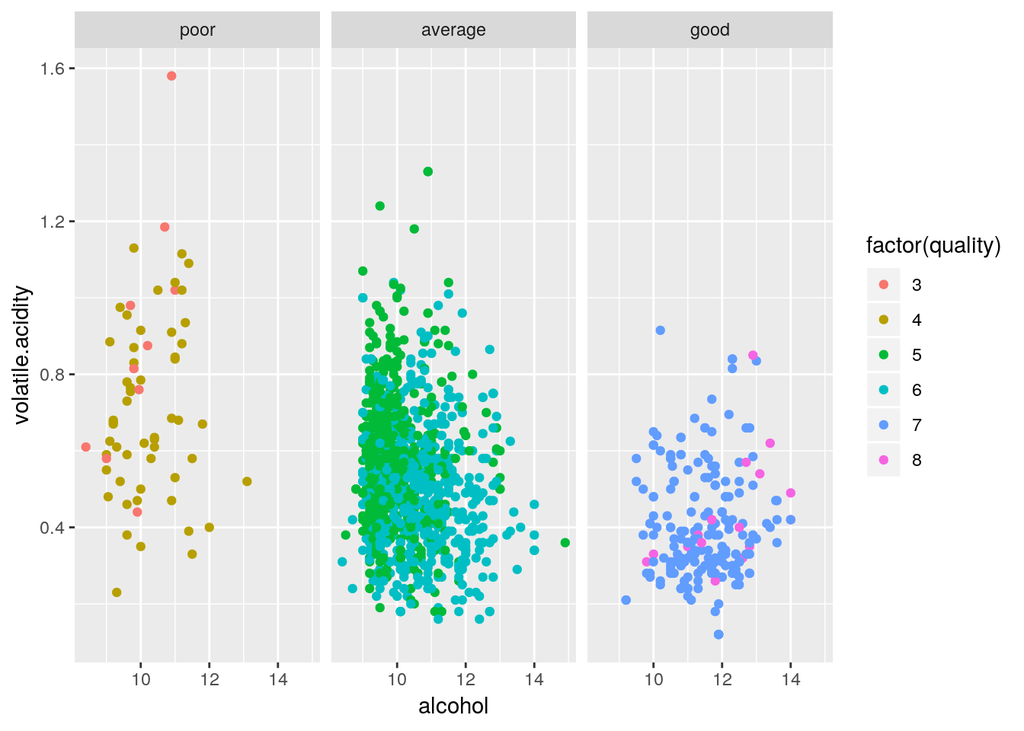

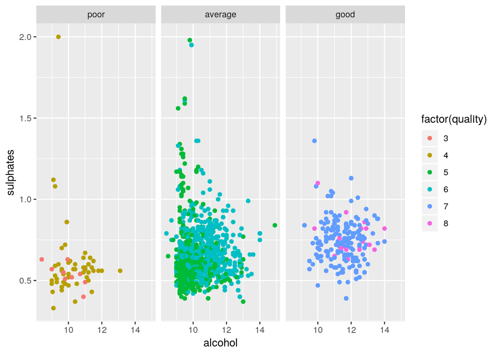

There are not strong correlation between alcohol content and sulphates across the wine ratings but red wines with a good rating have a more consistent concentration of sulphates with fewer outliers than the average and poor ratings.

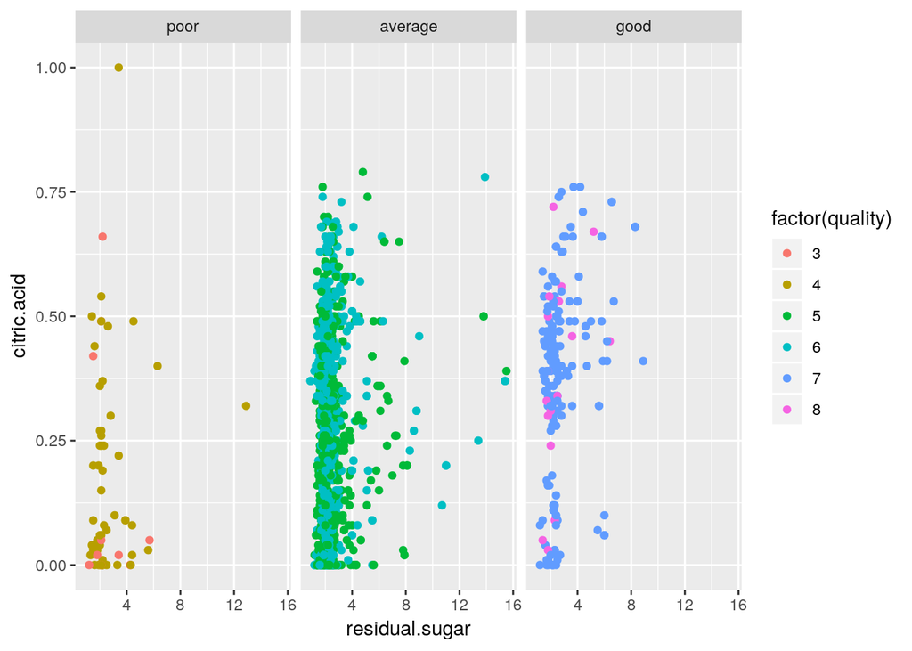

There is no strong correlation between residual sugar and citric acid across the wine ratings. The wines that have average and good rating show a similar distribution.

## Linear model

```
##
## Calls:
## m1: lm(formula = as.numeric(quality) ~ alcohol, data = reds)
## m2: lm(formula = as.numeric(quality) ~ alcohol + volatile.acidity,
##     data = reds)
## m3: lm(formula = as.numeric(quality) ~ alcohol + volatile.acidity +
##     sulphates, data = reds)
## m4: lm(formula = as.numeric(quality) ~ alcohol + volatile.acidity +
##     sulphates + fixed.acidity, data = reds)
## m5: lm(formula = as.numeric(quality) ~ alcohol + volatile.acidity +
##     sulphates + fixed.acidity + pH, data = reds)
## m6: lm(formula = as.numeric(quality) ~ alcohol + volatile.acidity +
##     sulphates + fixed.acidity + pH + citric.acid, data = reds)
##
## ========================================================================================================
##                          m1            m2            m3            m4            m5            m6
## --------------------------------------------------------------------------------------------------------
##   (Intercept)           1.875***      3.095***      2.611***      2.313***      2.904***      3.069***
##                        (0.175)       (0.184)       (0.196)       (0.223)       (0.575)       (0.575)
##   alcohol               0.361***      0.314***      0.309***      0.315***      0.320***      0.327***
##                        (0.017)       (0.016)       (0.016)       (0.016)       (0.016)       (0.017)
##   volatile.acidity                   -1.384***     -1.221***     -1.155***     -1.142***     -1.336***
##                                      (0.095)       (0.097)       (0.100)       (0.100)       (0.113)
##   sulphates                                         0.679***      0.642***      0.631***      0.688***
##                                                    (0.101)       (0.101)       (0.102)       (0.103)
##   fixed.acidity                                                   0.028**       0.018         0.045**
##                                                                  (0.010)       (0.013)       (0.015)
##   pH                                                                           -0.169        -0.251
##                                                                                (0.152)       (0.153)
##   citric.acid                                                                                -0.502***
##                                                                                              (0.138)
## --------------------------------------------------------------------------------------------------------
##   R-squared             0.227         0.317         0.336         0.339         0.340         0.345
##   adj. R-squared        0.226         0.316         0.335         0.337         0.338         0.343
##   sigma                 0.710         0.668         0.659         0.657         0.657         0.655
##   F                   468.267       370.379       268.912       204.457       163.839       139.780
##   p                     0.000         0.000         0.000         0.000         0.000         0.000
##   Log-likelihood    -1721.057     -1621.814     -1599.384     -1595.530     -1594.907     -1588.303
##   Deviance            805.870       711.796       692.105       688.776       688.240       682.578
##   AIC                3448.114      3251.628      3208.768      3203.061      3203.815      3192.605
##   BIC                3464.245      3273.136      3235.654      3235.323      3241.455      3235.622
##   N                  1599          1599          1599          1599          1599          1599
## ========================================================================================================
```

According to linear model the features of alcohol, volatile acidity, sulphates. fixed acidity. pH and citric acid only contribute 34.5% of the variance in wine quality.

# Multivariate Analysis

### Talk about some of the relationships you observed in this part of the investigation. Were there features that strengthened each other in terms of looking at your feature(s) of interest?

The plot with the strongest correlation was between alcohol and volatile acidity in the context of quality. Higher quality red wines had lower level of volatile acidity.

### Were there any interesting or surprising interactions between features?

I thought that residual sugar and citric acid would have a greater impact on the quality of the wine but in the case of average and good wines the distribution of data point is similar.

### OPTIONAL: Did you create any models with your dataset? Discuss the strengths and limitations of your model.

I created a linear model but the R-squared value of 0.345 does not do a good job of predicting wine quality. I suspect that this is due to much of the data not being linear in nature. Perhaps a non-linear model or more wine features could be used to create a more reliable model.

# Final Plots and Summary

### Plot One

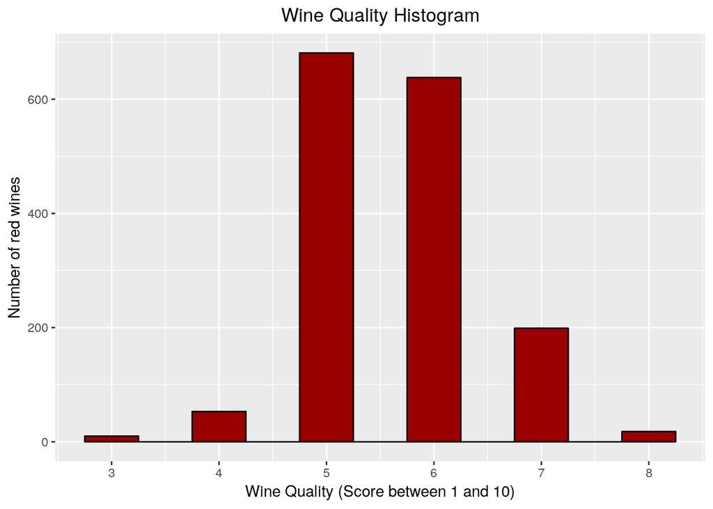

### Description One

The primary feature evaluated in this analysis is the wine quality. The plot shows that the vast majority of wines have a quality rating of 5 or 6 indicating average quality.

### Plot Two

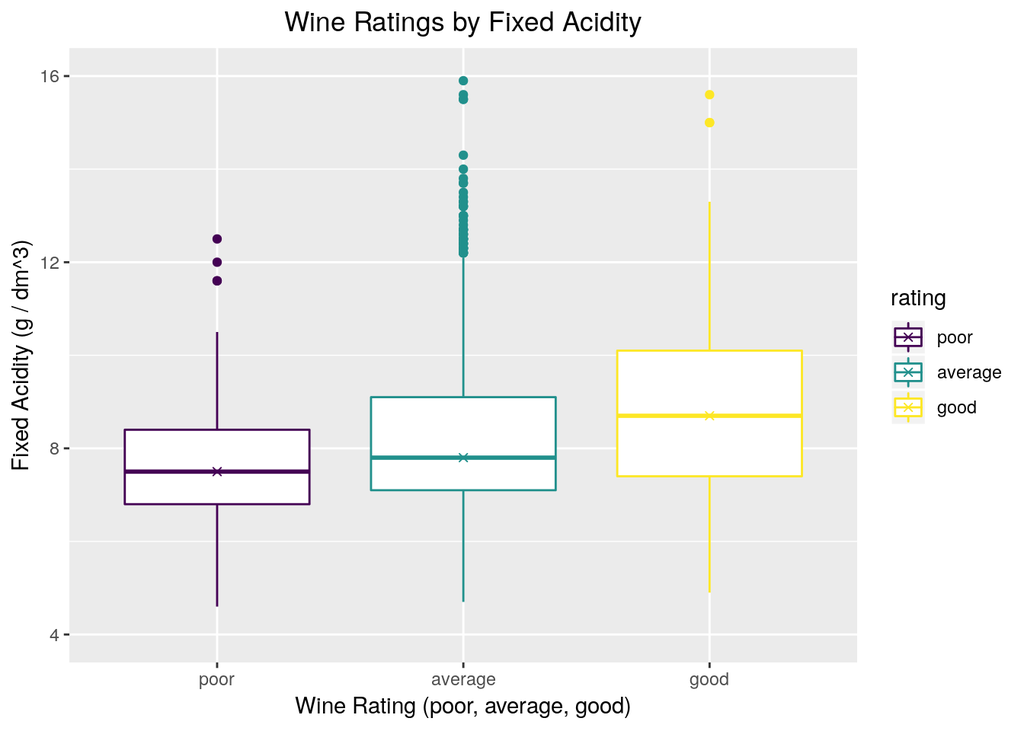

```
## reds$rating: poor
##    Min. 1st Qu.  Median    Mean 3rd Qu.    Max.
##   4.600   6.800   7.500   7.871   8.400  12.500
## --------------------------------------------------------
## reds$rating: average
##    Min. 1st Qu.  Median    Mean 3rd Qu.    Max.
##   4.700   7.100   7.800   8.254   9.100  15.900
## --------------------------------------------------------
## reds$rating: good
##    Min. 1st Qu.  Median    Mean 3rd Qu.    Max.
##   4.900   7.400   8.700   8.847  10.100  15.600
```

### Description Two

The fixed acidity content of the red wine has a clear correlation to the wine rating. Wines that are rated as good have higher fixed acidity content compared to wines with average or poor ratings.

### Plot Three

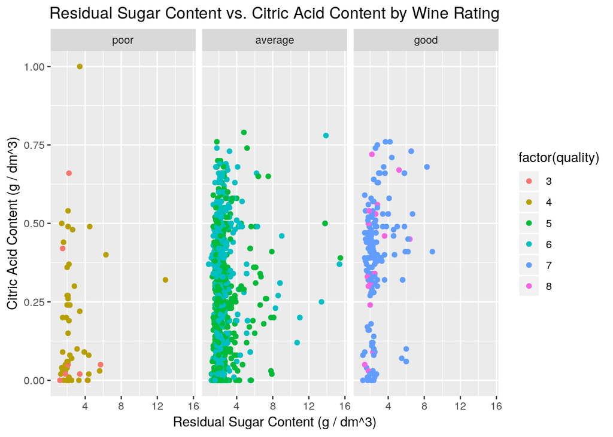

### Description Three

Residual sugar content versus citric acid content by wine rating shows that there is no significant difference in these features particularly across average and good wines.

# Reflection